# Clustering article - title tbd

Antal Ertl

2023-01-24

#PCA computation

Scree-plot: based on this, around 4 is the optimal number of clusters for PCA

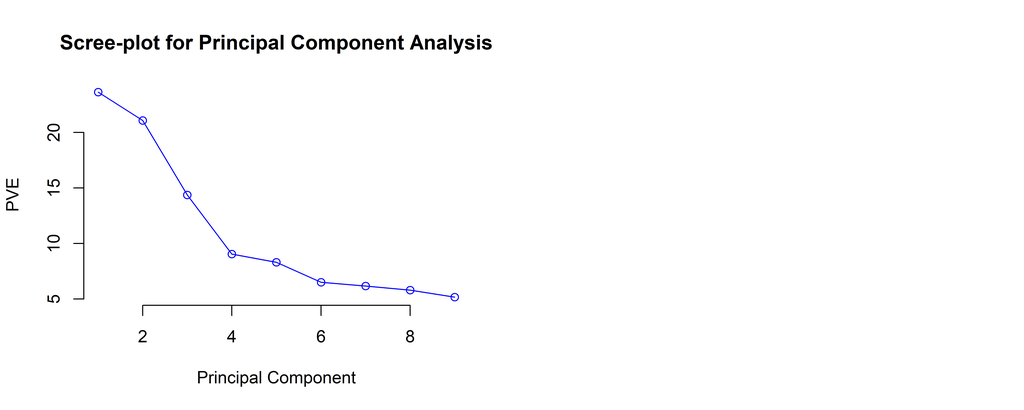

Parallel Analysis: specify how many components to retain using simulation

Here, we get the critical values for each component. If the eigenvalues from the PCA are greater than the value at 0.95 confint, we can retain given component.

[output not shown]

```
## Principal Components Analysis
## Call: psych::principal(r = ., nfactors = 5, rotate = "varimax")
## Standardized loadings (pattern matrix) based upon correlation matrix
##                       RC2   RC3   RC1   RC4   RC5   h2    u2 com
## delta               -0.75  0.05  0.15  0.16 -0.13 0.63 0.369 1.3
## beta                 0.78  0.04  0.11 -0.12 -0.09 0.65 0.352 1.1
## beta_0               0.80  0.06 -0.06  0.18 -0.05 0.68 0.322 1.1
## dictator             0.04  0.83  0.11 -0.10  0.13 0.74 0.262 1.1
## dictator_schoolmate  0.01  0.87  0.06 -0.02  0.07 0.76 0.237 1.0
## risk                -0.07 -0.12  0.12  0.95  0.00 0.93 0.073 1.1
## publicgood          -0.01  0.00  0.92 -0.03  0.05 0.84 0.158 1.0
## trust               -0.08  0.25  0.71  0.27  0.20 0.68 0.318 1.8
## trust_return        -0.02  0.19  0.17  0.00  0.95 0.97 0.034 1.1
##
##                        RC2  RC3  RC1  RC4  RC5
## SS loadings           1.82 1.57 1.44 1.05 0.99
## Proportion Var        0.20 0.17 0.16 0.12 0.11
## Cumulative Var        0.20 0.38 0.54 0.65 0.76
## Proportion Explained  0.26 0.23 0.21 0.15 0.14
## Cumulative Proportion 0.26 0.49 0.70 0.86 1.00
##
## Mean item complexity =  1.2
## Test of the hypothesis that 5 components are sufficient.
##
## The root mean square of the residuals (RMSR) is  0.08
##  with the empirical chi square  545.96  with prob <  9.5e-121
##
## Fit based upon off diagonal values = 0.84
```

Use varimax rotation for the data (just as Chapman et al.(2022) did) For 3 factors

```
##
## Loadings:
##                     RC1    RC2    RC3
## delta                      -0.747  0.175
## beta                        0.788
## beta_0                      0.792
## dictator             0.819
## dictator_schoolmate  0.792
## risk                -0.391         0.618
## publicgood           0.158         0.730
## trust                0.303         0.755
## trust_return         0.518         0.358
##
##                  RC1   RC2   RC3
## SS loadings    1.841 1.825 1.648
## Proportion Var 0.205 0.203 0.183
## Cumulative Var 0.205 0.407 0.590
```

Graph of the contents of the 3 components:

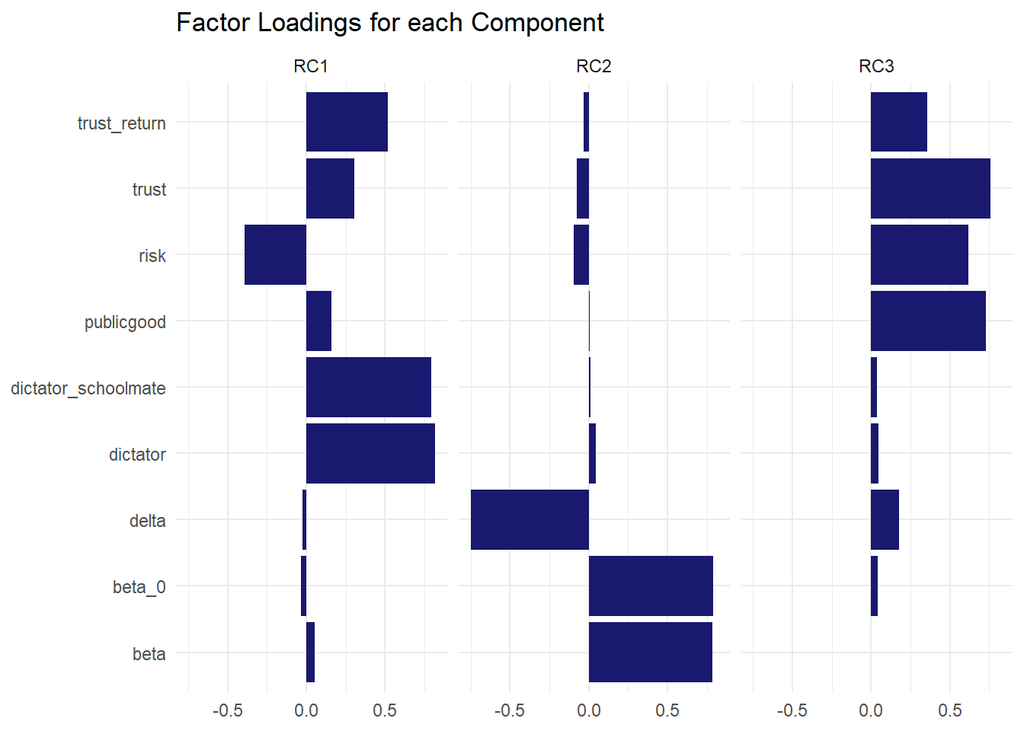

PCA for 4 factors:

```
##
## Loadings:
##                     RC2    RC1    RC3    RC4
## delta               -0.745                0.206
## beta                 0.786
## beta_0               0.796                0.183
## dictator                    0.158  0.831
## dictator_schoolmate                0.860
## risk                        0.104 -0.108  0.925
## publicgood                  0.841
## trust                       0.719  0.230  0.305
## trust_return                0.580  0.321 -0.185
##
##                  RC2   RC1   RC3   RC4
## SS loadings    1.822 1.619 1.608 1.079
## Proportion Var 0.202 0.180 0.179 0.120
## Cumulative Var 0.202 0.382 0.561 0.681
```

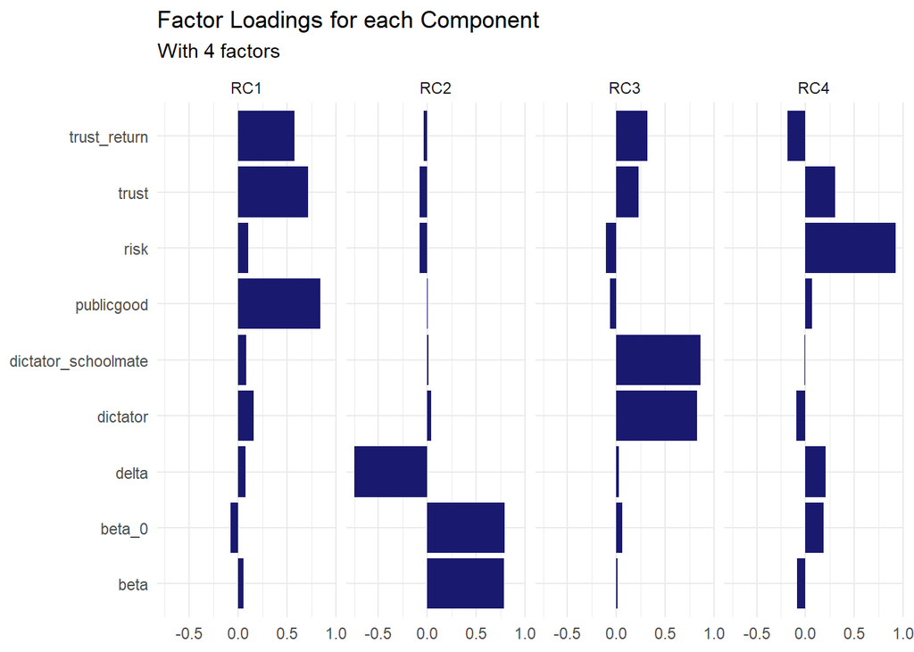

# PCA including competition

Here, I do the same analysis, but I include the interaction term ‘STournamentChoosed_comp = STournamentChoosed* comp’

Scree-plot and Parallel analysis says pretty much the same.

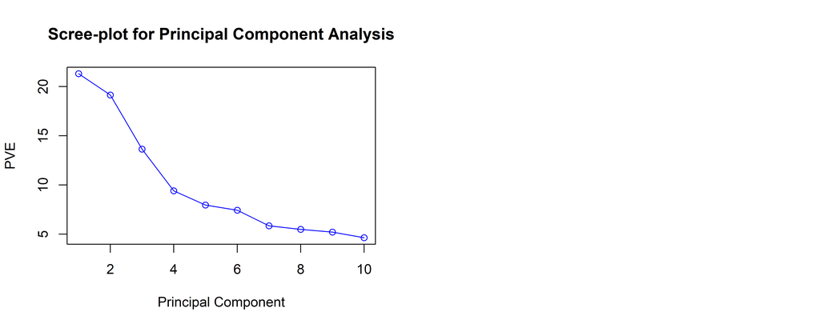

[output not shown]

```
## Principal Components Analysis
## Call: psych::principal(r = ., nfactors = 5, rotate = "varimax")
## Standardized loadings (pattern matrix) based upon correlation matrix
##                           RC2   RC1   RC5   RC3   RC4   h2    u2 com
## delta                   -0.74  0.07  0.03  0.21  0.04 0.61 0.394 1.2
## beta                     0.79  0.05  0.02 -0.05 -0.08 0.63 0.369 1.0
## beta_0                   0.80 -0.07  0.07  0.16  0.10 0.68 0.322 1.1
## dictator                 0.04  0.16  0.83 -0.09 -0.09 0.73 0.267 1.1
## dictator_schoolmate      0.01  0.08  0.86 -0.02  0.02 0.76 0.245 1.0
## risk                    -0.08  0.13 -0.10  0.89  0.10 0.84 0.160 1.1
## publicgood               0.00  0.83 -0.05  0.09 -0.02 0.70 0.300 1.0
## trust                   -0.08  0.72  0.24  0.30  0.00 0.68 0.324 1.6
## trust_return            -0.04  0.60  0.29 -0.30  0.14 0.55 0.446 2.1
## STournamentChoosed_comp -0.02  0.05 -0.05  0.09  0.98 0.97 0.033 1.0
##
##                        RC2  RC1  RC5  RC3  RC4
## SS loadings           1.82 1.63 1.60 1.07 1.01
## Proportion Var        0.18 0.16 0.16 0.11 0.10
## Cumulative Var        0.18 0.35 0.51 0.61 0.71
## Proportion Explained  0.26 0.23 0.22 0.15 0.14
## Cumulative Proportion 0.26 0.48 0.71 0.86 1.00
##
## Mean item complexity =  1.2
## Test of the hypothesis that 5 components are sufficient.
##
## The root mean square of the residuals (RMSR) is  0.09
##  with the empirical chi square  775.63  with prob <  2.2e-165
##
## Fit based upon off diagonal values = 0.77
```

Use varimax rotation for the data (just as Chapman et al.(2022) did) For 3 components

```
##
## Loadings:
##                         RC1    RC2    RC3
## delta                          -0.747  0.175
## beta                            0.784
## beta_0                          0.797
## dictator                 0.783        -0.209
## dictator_schoolmate      0.746        -0.178
## risk                    -0.161 -0.101  0.694
## publicgood               0.405         0.583
## trust                    0.545         0.577
## trust_return             0.605         0.173
## STournamentChoosed_comp -0.117         0.488
##
##                  RC1   RC2   RC3
## SS loadings    2.041 1.829 1.536
## Proportion Var 0.204 0.183 0.154
## Cumulative Var 0.204 0.387 0.541
```

Graph of the contents of the 3 components:

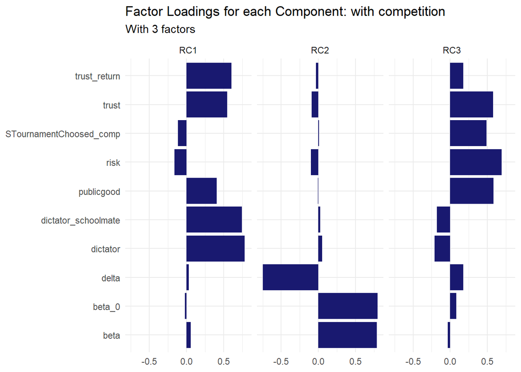

With 4 components:

```
##
## Loadings:
##                         RC2    RC1    RC3    RC4
## delta                   -0.748         0.148  0.103
## beta                     0.787
## beta_0                   0.792                0.152
## dictator                        0.817
## dictator_schoolmate             0.819
## risk                           -0.349  0.507  0.358
## publicgood                             0.786
## trust                           0.265  0.771
## trust_return                    0.499  0.383
## STournamentChoosed_comp                       0.946
##
##                  RC2   RC1   RC3   RC4
## SS loadings    1.827 1.788 1.648 1.082
## Proportion Var 0.183 0.179 0.165 0.108
## Cumulative Var 0.183 0.361 0.526 0.635
```

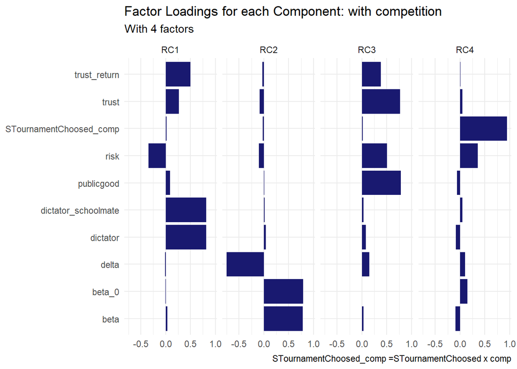

# FAMD - Factor Analysis for Mixed Data

FAMD is essentially a PCA method we can use for both continuous and categorical data (a mix between PCA and MCA)

From FactoMineR package:

“FAMD is a principal component method dedicated to explore data with both continuous and cate- gorical variables. It can be seen roughly as a mixed between PCA and MCA. More precisely, the continuous variables are scaled to unit variance and the categorical variables are transformed into a disjunctive data table (crisp coding) and then scaled using the specific scaling of MCA. This ensures to balance the influence of both continous and categorical variables in the analysis. It means that both variables are on a equal foot to determine the dimensions of variability. This method allows one to study the similarities between individuals taking into account mixed variables and to study the relationships between all the variables. It also provides graphical outputs such as the repre- sentation of the individuals, the correlation circle for the continuous variables and representations of the categories of the categorical variables, and also specific graphs to visulaize the associations between both type of variables.”

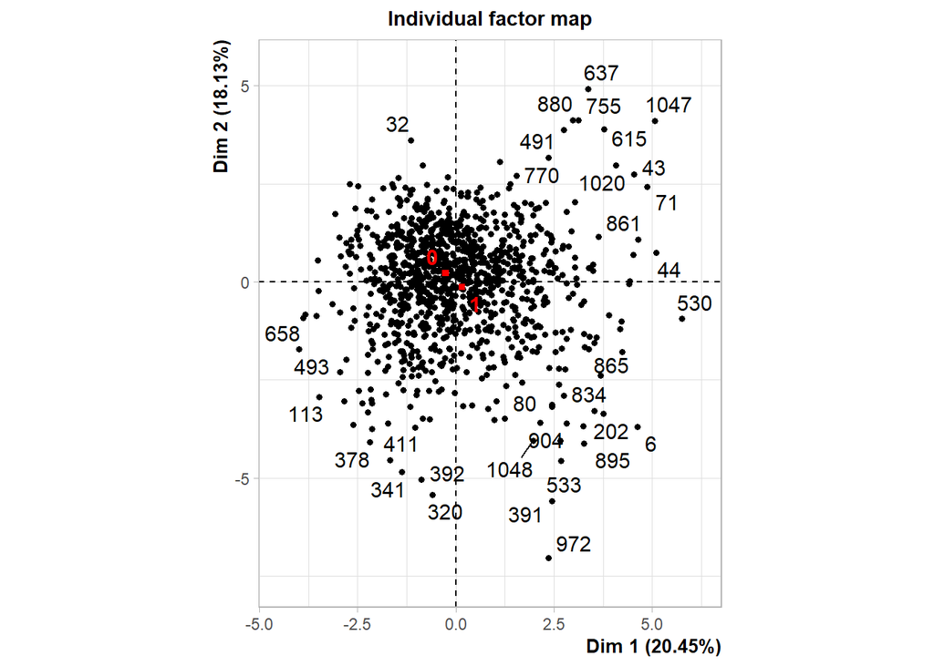

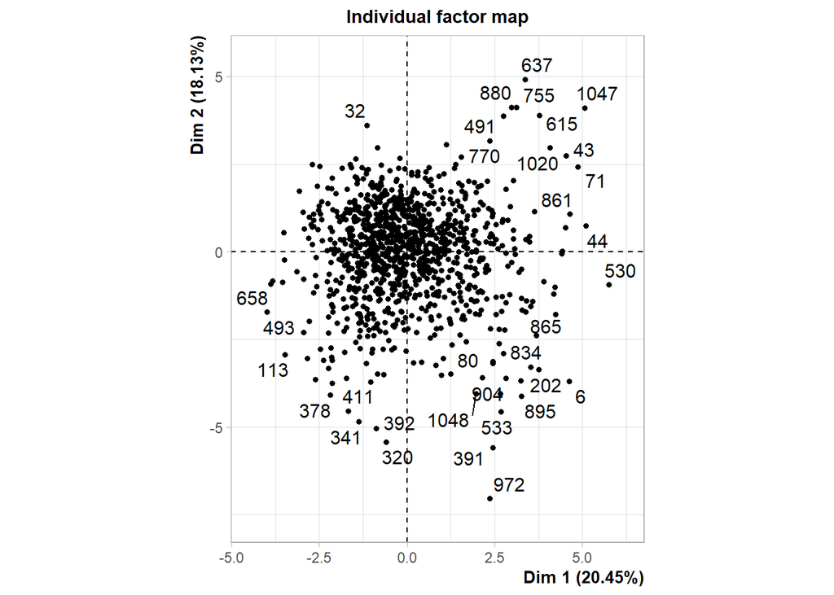

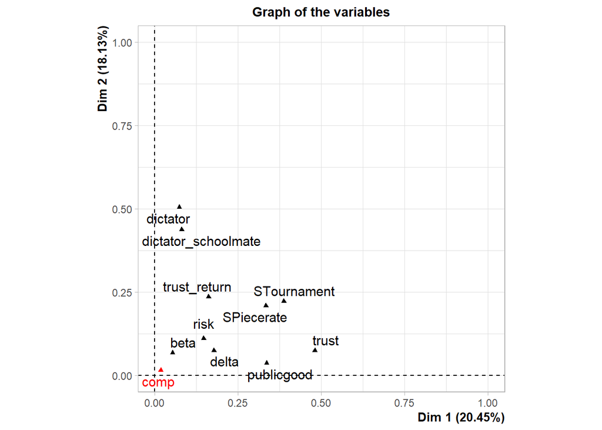

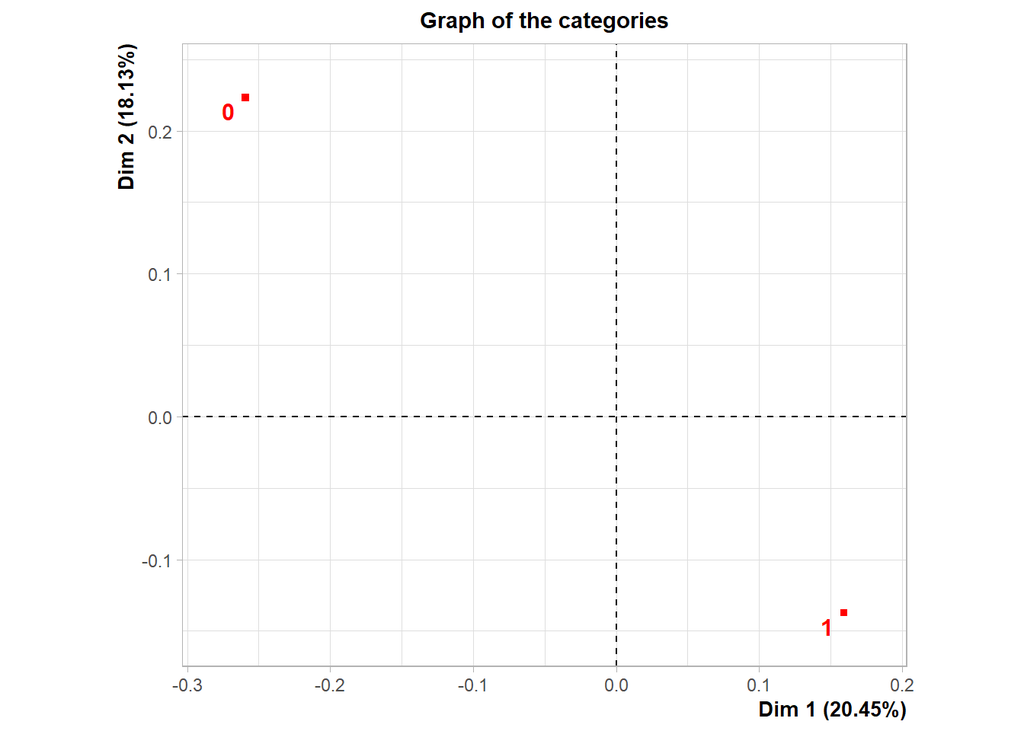

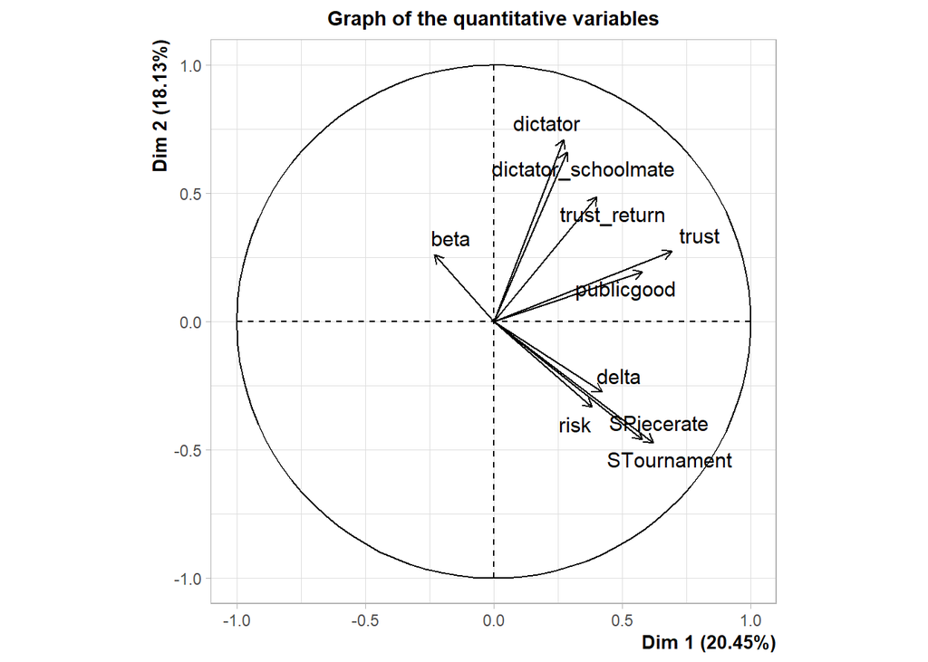

```
##
## Call:
## FAMD(base = FAMD_data, ncp = 4, graph = TRUE, sup.var = NULL,
##      ind.sup = NULL, axes = c(1, 2), row.w = NULL, tab.disj = NULL)
##
##
## Eigenvalues
##                       Dim.1  Dim.2  Dim.3  Dim.4
## Variance              2.249  1.994  1.290  1.121
## % of var.            20.450 18.131 11.725 10.190
## Cumulative % of var. 20.450 38.580 50.305 60.495
##
## Individuals (the 10 first)
##                         Dist    Dim.1    ctr   cos2    Dim.2    ctr   cos2
## 1                   |  2.662 |  1.725  0.125  0.420 |  0.110  0.001  0.002 |
## 2                   |  3.034 | -1.326  0.074  0.191 | -2.004  0.190  0.436 |
## 3                   |  2.946 | -2.141  0.193  0.529 |  0.575  0.016  0.038 |
## 4                   |  3.933 | -1.007  0.043  0.066 | -2.886  0.394  0.538 |
## 5                   |  3.751 |  2.269  0.216  0.366 | -1.351  0.086  0.130 |
## 6                   |  6.989 |  4.630  0.900  0.439 | -3.694  0.646  0.279 |
## 7                   |  2.548 |  1.177  0.058  0.213 |  1.061  0.053  0.173 |
## 8                   |  2.349 | -0.582  0.014  0.061 |  0.262  0.003  0.012 |
## 9                   |  2.049 | -0.417  0.007  0.041 | -1.071  0.054  0.273 |
## 10                  |  4.185 | -2.935  0.362  0.492 |  0.646  0.020  0.024 |
##                      Dim.3    ctr   cos2
## 1                    1.329  0.129  0.249 |
## 2                    0.096  0.001  0.001 |
## 3                    0.726  0.039  0.061 |
## 4                   -0.184  0.002  0.002 |
## 5                    1.409  0.145  0.141 |
## 6                    2.528  0.468  0.131 |
## 7                   -0.228  0.004  0.008 |
## 8                    1.646  0.198  0.491 |
## 9                   -0.499  0.018  0.059 |
## 10                   1.816  0.241  0.188 |
##
## Continuous variables
##                        Dim.1    ctr   cos2    Dim.2    ctr   cos2    Dim.3
## delta               |  0.421  7.891  0.178 | -0.275  3.788  0.076 | -0.592
## beta                | -0.231  2.381  0.054 |  0.261  3.410  0.068 |  0.741
```

[output cut: 12 more lines]

```
## dictator_schoolmate  0.003  0.000 |
## risk                 1.581  0.020 |
## publicgood           0.156  0.002 |
## trust                0.157  0.002 |
## trust_return         0.535  0.007 |
## SPiecerate          15.015  0.194 |
## STournament         12.692  0.164 |
##
## Categories
##                        Dim.1    ctr   cos2 v.test    Dim.2    ctr   cos2 v.test
## 0                   | -0.259  0.506  0.039 -4.409 |  0.223  0.477  0.029  4.032
## 1                   |  0.159  0.311  0.039  4.409 | -0.137  0.293  0.029 -4.032
##                        Dim.3    ctr   cos2 v.test
## 0                   |  0.037  0.031  0.001  0.831 |
## 1                   | -0.023  0.019  0.001 -0.831 |
```

# Clustering test

Here I am combining clustering methods (k-means) with PCA to visualize clusters. I did it for various numbers of cluster-centers.

Overall, we can’t really show in 2 dimensions the effectiveness of clustering.

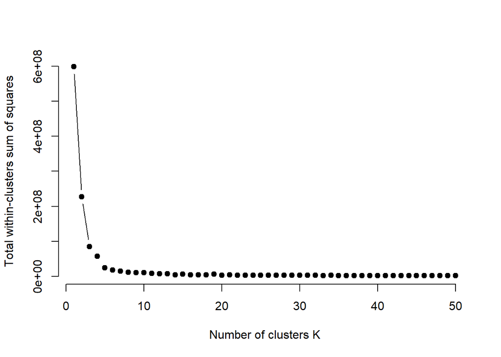

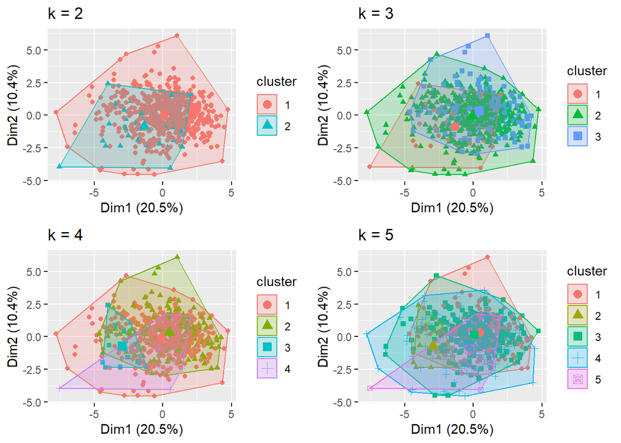